# Informe N51 Semanal de Covid-19

# Aysén, Atacama y Los Lagos llegan a un nivel alto de contagios.

En este informe presentamos el Analisis Semanal Nº51 de Covid-19 elaborado por el Grupo Epidemiológico Matemático para la Vigilancia de Epidemias y Pandemia (GEMVEP) de la Universidad de Santiago. Los datos usados en este informe consideran los casos de Covid-19 informados entre el 16 de Noviembre y el 22 de Noviembre .Los datos provienen de las siguientes fuentes de información:

## Balance Semanal

Aysen 46.47 casos cada 100.000 habitantes  
Atacama 24.42  
Los Lagos 21.2  
Bio-Bio 17.83  
Tarapaca 15.75  
Los Rios 14.57  
Valparaiso 13.34

Las regiones con las menores tasas de incidencia promedio en la ultima semana son:

Arica 8.5 casos cada 100.000 habitantes  
Ohiggins 6.8  
Magallanes 6.33

Actualmente, 11 de 16 regiones del país tienen un nivel crítico de contagios.

Además, 10 de 16 regiones del país han aumentado casos de Covid-19 en los últimos 7 días. Las regiones con los mayores aumentos de casos de Covid-19 en la ultima semana son:

Los Lagos + 37.38 %  
Atacama + 28.4 %  
Nuble + 20.06 %  
Coquimbo + 14.4 %  
Bio-Bio + 14.07 %  
Mientras que las regiones con las mayores disminuciones de casos de Covid-19 en la ultima semana son:

Magallanes -24.76 %  
Arica -27.88 %  
Los Rios -32.46 %

En la siguiente figura mostramos nuestro balance de indicadores de circulación del Covid-19 por región del país en la ultima semana.

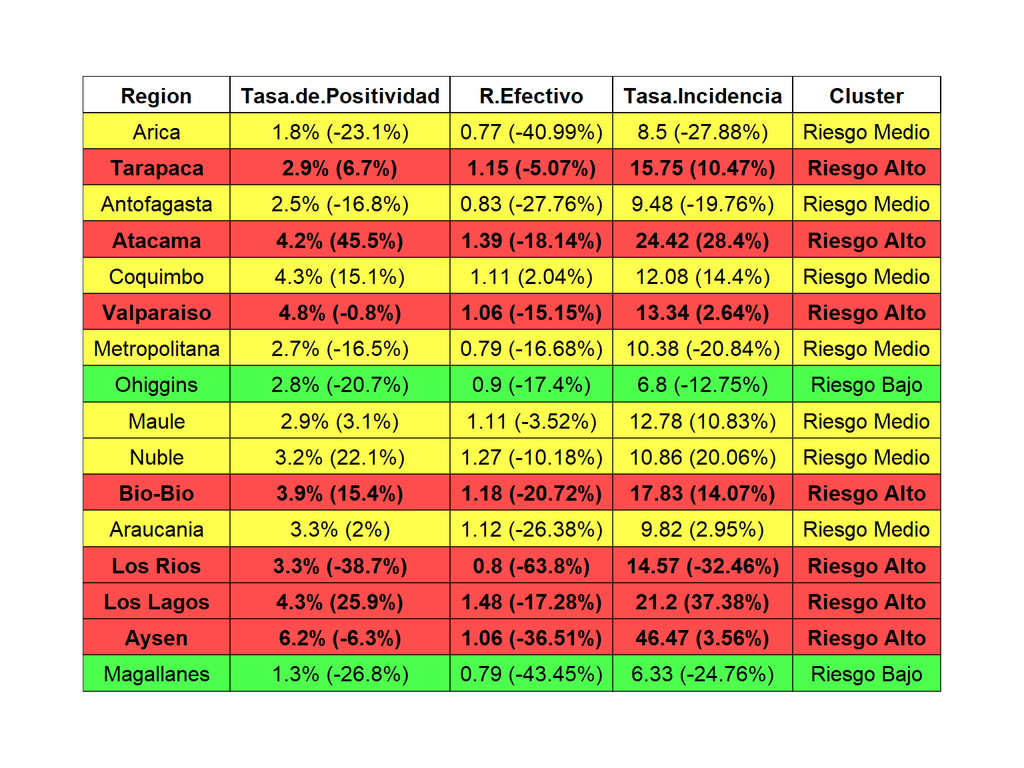

Balance Semanal: Tasa de Incidencia es número de casos nuevos en la última semana cada 100.000 habitantes, Tasa de positividad es numero de casos nuevos confirmados con PCR dividido numero de examenes PCR por semana

Damos alerta en las regiones de Tarapaca, Atacama, Valparaiso, Bio-Bio, Los Rios, Los Lagos, y Aysen .Además, la región de Aysen tiene la mayor tasa de Positividad con ( 6.2 %) y la region de Los Lagos tiene el mayor R efectivo con ( 1.5 )

## Hospitalizaciones

El número de pacientes con Covid-19 en UCI informados el 18 de Noviembre fue 624 ( 54 mas que semana previa) . Además, este día se informaron 527 pacientes Covid-19 en ventilación mecánica invasiva (VMI) ( 54 menos que semana previa) .  
Las regiones con mayor porcentaje de ocupación UCI al día son:

Valparaiso 98.14 %  
Nuble 95.08 %  
Araucania 94.52 %  
Los Rios 89.66 %  
Coquimbo 89.51 %  
Este dia, 8 de las 16 regiones del país tuvieron una ocupación de camas UCI superior al 80%.Las regiones que tuvieron menor ocupación UCI son:

Aysen 61.11 %  
Bio-Bio 60 %  
Atacama 53.33 %

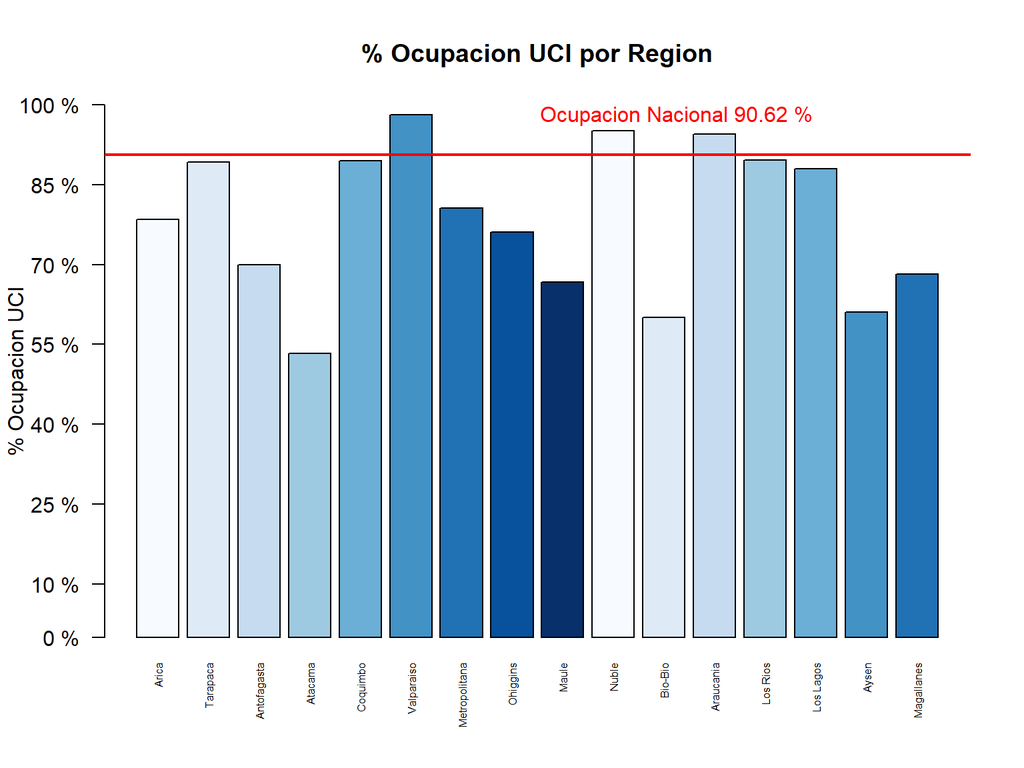

Porcentaje de Ocupación UCI por Region

Las regiones con menor cantidad de camas UCI disponibles son:

Tarapaca 3 camas UCI disponibles  
Valparaiso 3  
Bio-Bio 4  
Araucania 4  
Los Lagos 6  
Las regiones con mayor proporción de camas UCI usadas sobre el basal de camas UCI disponibles en 2019 son:

Tarapaca 208.33 %  
Antofagasta 175 %  
Los Rios 159.18 %  
Los Lagos 151.72 %  
Coquimbo 149.48 %  
Este dia, 11 de las 16 regiones del país tienen una ocupación sobre el 100% de camas bases del año 2019.

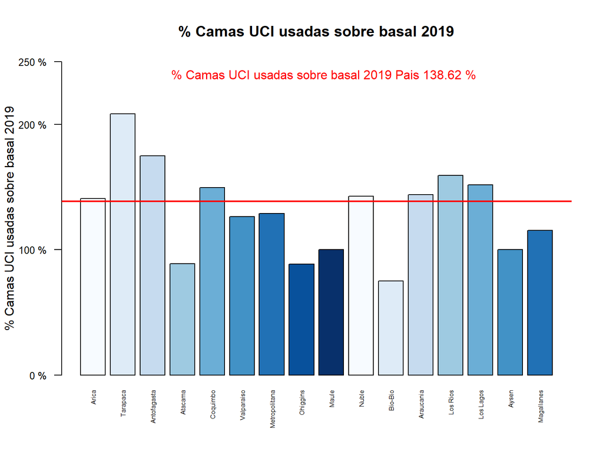

Porcentaje de Ocupación UCI sobre basal de camas disponibles en 2019 por Region

## Situación Comunal

En el analisis comunal notamos que 201 de 346 comunas del país tienen un nivel crítico de contagios.

Las comunas de más de 25.000 habitantes con las mayores tasas de incidencia promedio en la ultima semana son:

Aysen 76.57 casos cada 100.000 habitantes  
Coyhaique 46.44  
Vallenar 37.34  
Cartagena 36.06  
Calera de Tango 32.05

Panguipulli 30.96  
Osorno 29.49  
Valdivia 29.25  
Padre Hurtado 29.08

San Antonio 27.9

Las comunas de más de 25.000 habitantes con mayor aumento de casos en la ultima semana son:

Carahue + 67.86 %  
Angol + 66.67 %  
Arauco + 54.29 %  
El Monte + 37.76 %  
Valdivia + 34.97 %  
Freire + 33.33 %  
Canete + 30 %  
Osorno + 25.36 %  
Chillan Viejo + 22.08 %  
Calama + 21.5 %

## Análisis de Cambio de tendencia

Para este análisis se consideran los casos reportados en las ultimas 6 semanas.

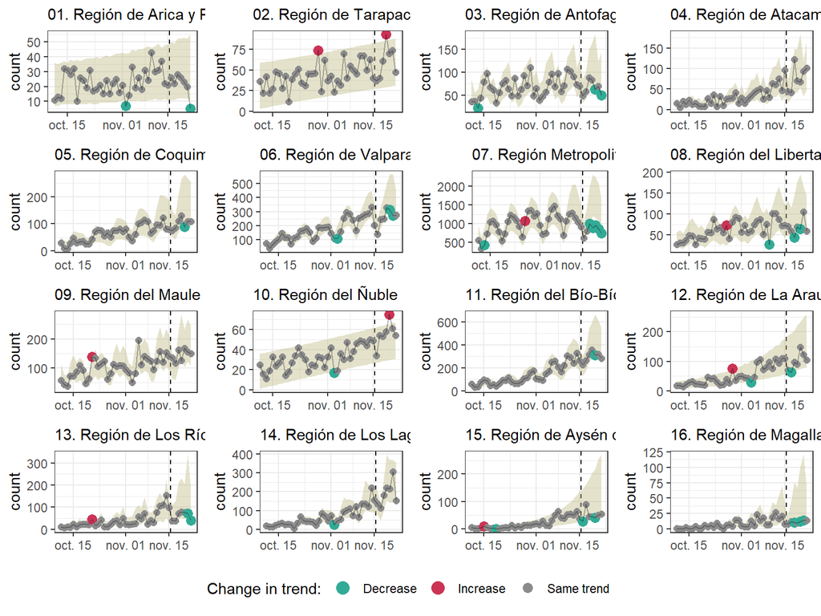

# Indicadores usados:

- R Efectivo: La tasa de reproducción efectiva fue calculada a nivel regional usando el método de Cori implementado en el paquete EpiEstim de R.
- Tasa de Incidencia: Casos Diarios cada 100.000 habitantes promedio en los últimos 7 días.
- Tasa de Positividad: Casos Confirmados por Test PCR dividido el número de exámenes PCR en la última semana.
- Variación de Casos: Corresponde a la variación relativa de casos en la semana vigente respecto a la semana previa.

Para la definición de regiones en Riesgo Alto, Medio y Bajo se usa un procedimiento de cluster que se basa en incidencia, positividad y R efectivo en ultimos 7 días y su variación respecto a la semana anterior.